# Reproducible Results for Motor Control in Individuals with Autistic Traits

Deborah Apthorp

2023-04-14

## Results

Descriptive statistics of the key variables overall and stratified by gender.

|  | Overall | Female | Male | p |
| --- | --- | --- | --- | --- |
| n | 158 | 111 | 47 |  |
| Age (years) (mean (SD)) | 35.41 (14.54) | 35.01 (14.48) | 36.36 (14.78) | 0.594 |
| AQ-10 score (mean (SD)) | 3.08 (1.82) | 3.02 (1.91) | 3.23 (1.59) | 0.496 |
| Dominant hand score (mean (SD)) | 66.38 (9.75) | 64.46 (8.50) | 70.91 (11.03) | <0.001 |
| Non-dominant hand score (mean (SD)) | 61.07 (8.32) | 59.81 (8.30) | 64.06 (7.66) | 0.003 |

## Preliminary Analysis

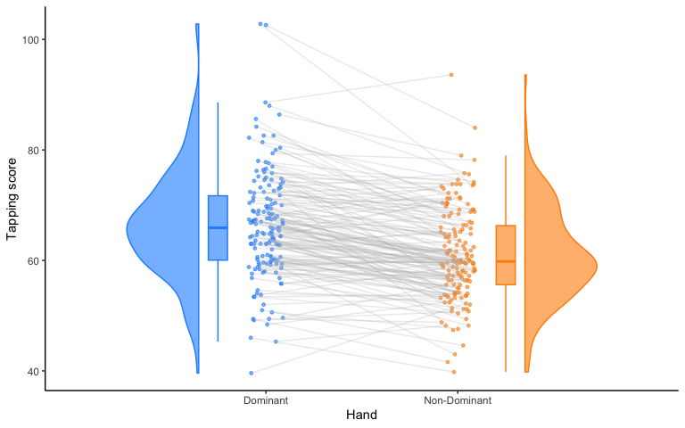

Observed differences between mean hand tapping scores. Individuals’ scores are connected with grey lines, and distributions are shown on the outside of the plots.

## Correlational Analysis

As assumptions of normality were violated, Spearman’s correlation analyses were run for each hand to assess the associations between AQ-10 score, age, gender and tapping scores (see Table 2).

Correlations between key variables and tapping scores

|  | 1 | 2 | 3 | 4 |
| --- | --- | --- | --- | --- |
| 1. Age | - |  |  |  |
| 2. Gender | .06 | - |  |  |
| 3. AQ.10.score | -.36*** | .09 | - |  |
| 4. values.score_dominant | -.16 | .27*** | -.07 | - |
| 5. values.score_nondominant | -.07 | .24** | -.10 | .73*** |

*Note*: * p < 0.05; ** p < 0.01; *** p < 0.001.

Based on these analyses, age was negatively associated with AQ-10 score and only gender was found to be positively correlated with tapping scores for both hands (such that male participants had higher tapping scores than females - also evident in Table 1). These correlations reflected small to medium effect sizes (Cohen, 1988).

## Regression Analysis

Two general linear model analyses (GLMs) were carried out to investigate the influence autistic traits in the general population (AQ-10 scores), age, and gender have on fine motor skills (FTT scores). Both Q-Q plots showed that the data was normally distributed, Kolmogorov-Smirnov test and the Shapiro-Wilk’s W test were both not significant ($W = .984, p = .059, D = .054, p = .743$ dominant; $W = .948, p = .057, D = .083, p = .226$ non-dominant). Levene’s test indicated no violations to the assumption of homogeneity of variance for either hand ($p =.114$ dominant, $p = .235$ non-dominant). Following the recommendations of Cohen (2013), AQ-10 scores and age were centred at zero and gender was dummy-coded.

Model regressing gender, AQ-10 score, and age on dominant hand tapping scores

| term | estimate | conf.int | statistic | df | p.value |
| --- | --- | --- | --- | --- | --- |
| Intercept | 82.63 | [74.96, 90.30] | 21.28 | 153 | < .001 |
| AQ 10 score | -3.79 | [-5.78, -1.79] | -3.74 | 153 | < .001 |
| Age | -0.39 | [-0.58, -0.20] | -4.08 | 153 | < .001 |
| Gender | 6.44 | [3.41, 9.48] | 4.19 | 153 | < .001 |
| AQ 10 score $\times$ Age | 0.07 | [0.01, 0.13] | 2.48 | 153 | .014 |

*Note*: $R^2 = .22$, 90% CI $[0.12, 0.31]$, $R^2_{adj} = .20$. $B$ = unstandardised regression coefficient, $SE$ = standard error, $\beta$ = standardised regression coefficient $CI$ = confidence interval, $t$ = t-test value, $p$ = probability.

Model regressing gender, AQ-10 score, and age on non-dominant hand tapping scores

| term | estimate | conf.int | statistic | df | p.value |
| --- | --- | --- | --- | --- | --- |
| Intercept | 70.22 | [63.24, 77.20] | 19.88 | 153 | < .001 |
| AQ 10 score | -2.13 | [-3.95, -0.31] | -2.32 | 153 | .022 |
| Age | -0.21 | [-0.38, -0.04] | -2.44 | 153 | .016 |
| Gender | 4.32 | [1.55, 7.08] | 3.09 | 153 | .002 |
| AQ 10 score $\times$ Age | 0.04 | [-0.02, 0.09] | 1.37 | 153 | .173 |

*Note*: $R^2 = .12$, 90% CI $[0.03, 0.19]$, $R^2_{adj} = .10$. $B$ = unstandardised regression coefficient, $SE$ = standard error, $\beta$ = standardised regression coefficient $CI$ = confidence interval, $t$ = t-test value, $p$ = probability.

The overall models were both statistically significant, explaining $22\%$ of the variance for dominant, $R^2 = .22$, 90% CI $[0.12, 0.31]$, $F(4, 153) = 11.04$, $p < .001$, and $12\%$ of the variance for non-dominant hands, $R^2 = .12$, 90% CI $[0.03, 0.19]$, $F(4, 153) = 5.20$, $p = .001$. Gender, AQ-10 score, age, and the interaction between AQ-10 and age explained significant amounts of unique variance in finger tapping scores in the dominant hand (see Table 3. Only gender, AQ-10 score, and age explained significant amounts of unique variance in finger tapping scores in the non-dominant hand (see Table 4). When age or AQ-10 scores increased, tapping decreased for both hands.

A simple slopes analysis of the moderating effect of age on the relationship between AQ-10 scores and tapping scores, using Johnson-Neyman intervals.

| Value of Age | Est. | S.E. | 2.5% | 97.5% | t val. | p |
| --- | --- | --- | --- | --- | --- | --- |
| 20.87476 | -2.2648905 | 0.5155617 | -3.283429 | -1.2463517 | -4.3930539 | 0.0000208 |
| 35.41139 | -1.2062157 | 0.4242756 | -2.044411 | -0.3680209 | -2.8430003 | 0.0050798 |
| 49.94803 | -0.1475409 | 0.6764979 | -1.484024 | 1.1889419 | -0.2180951 | 0.8276456 |

To interpret the interaction in the dominant hand, a simple effects plot with standardised slopes was generated as seen in Figure 2. Statistical test values are shown in Table 5. Examination of the simple slope coefficients revealed that for the younger participants ($-1 SD$), there was a significant negative linear relationship between AQ-10 scores and tapping scores. When participants were closer to the mean age there was also a significant negative linear relationship between AQ-10 scores and tapping scores, but with a shallower slope. For older participants ($+1 SD$), there was no significant relationship between AQ-10 scores and tapping scores.

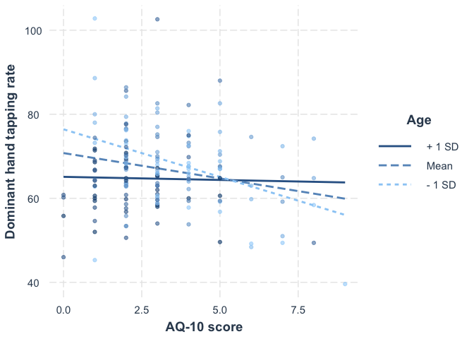

A simple slopes plot illustrating the interaction between age and AQ-10 score for the dominant hand tapping data

## Exploratory results

We were interested in exploring any interaction effects of gender with AQ scores; although there was no significant difference between male and female participants on mean AQ score (see Table 1), it is possible that there may have been a moderating effect of gender on the relationship between AQ score and tapping rate. Accordingly, we carried out an exploratory analysis including the interaction between gender and AQ-10 score in each regression model (for the dominant and non-dominant hand). The interaction was not significant in either model.

Model regressing gender, AQ-10 score, age, and the interactions between age and AQ-10 score and AQ-10 score and gender, on dominant hand tapping scores

| term | estimate | conf.int | statistic | df | p.value |
| --- | --- | --- | --- | --- | --- |
| Intercept | 81.13 | [73.16, 89.09] | 20.13 | 152 | < .001 |
| AQ 10 score | -3.35 | [-5.44, -1.25] | -3.15 | 152 | .002 |
| Age | -0.37 | [-0.56, -0.18] | -3.87 | 152 | < .001 |
| Gender | 10.42 | [3.84, 17.00] | 3.13 | 152 | .002 |
| AQ 10 score $\times$ Age | 0.07 | [0.01, 0.13] | 2.32 | 152 | .022 |
| AQ 10 score $\times$ Gender | -1.24 | [-3.06, 0.58] | -1.35 | 152 | .180 |

Model regressing gender, AQ-10 score, age, and the interactions between age and AQ-10 score and AQ-10 score and gender, on non-dominant hand tapping scores

| term | estimate | conf.int | statistic | df | p.value |
| --- | --- | --- | --- | --- | --- |
| Intercept | 69.62 | [62.35, 76.90] | 18.90 | 152 | < .001 |
| AQ 10 score | -1.96 | [-3.87, -0.04] | -2.02 | 152 | .045 |
| Age | -0.21 | [-0.38, -0.03] | -2.33 | 152 | .021 |
| Gender | 5.90 | [-0.12, 11.91] | 1.94 | 152 | .055 |
| AQ 10 score $\times$ Age | 0.03 | [-0.02, 0.09] | 1.29 | 152 | .200 |
| AQ 10 score $\times$ Gender | -0.49 | [-2.16, 1.17] | -0.59 | 152 | .559 |